# 4. 词典分词

Natural Language Processing I

4. 词典分词

WU Xiaokun 吴晓堃

xkun.wu [at] gmail

2022/03/18

# 词、词典

## 分，还是不分？

```
小鸡炖蘑菇。

小鸡 炖 蘑菇。
```

[HanLP 在线分析](https://hanlp.hankcs.com/?sentence=%E5%A4%A9%E7%8E%8B%E7%9B%96%E5%9C%B0%E8%99%8E%EF%BC%8C%E5%B0%8F%E9%B8%A1%E7%82%96%E8%98%91%E8%8F%87%E3%80%82)

## 为什么要分词

- 语义理解依赖于正确的分词
  - 词：语义的最小单位
  - 现代汉语
- 很多 NLP 算法依赖于分词

两大类分词算法

- 词典规则：约定俗成或专家指定
- 机器学习：从数据本身进行分析

## 词

语言学定义：具备**独立语义的最小单元**

- 这个定义没有实际应用价值
  - 什么叫“最小单元”？

例如：小明的妈妈喊他回家吃饭

```
吃饭！
吃什么饭？
小鸡炖蘑菇。
谁炖的蘑菇？！
```

注意：汉字本身具有实意，特别是古汉语

```
妻子
```

```
“玷污……玷是一个动作，污是一个结果” -- 李敖在北大的演讲
```

## 词典分词

现实语言中，词汇和语法是不断发展变化的

- 需要一个**相对稳定的参考**

词典分词：只认词典里面的字符串

- 谁来编制词典？
- 如何更新词典？

## Zipf 定律

一个单词的词频与其词频排名成反比

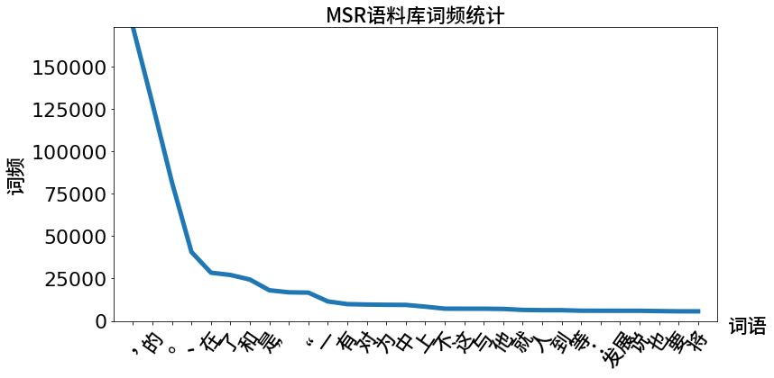

- MSR 语料库
- 大致符合幂律分布（长尾效应）：罕见词很多但影响不大

## HanLP 词典

```
希望  v   386 n   96  vn  25  nz  1
希特勒 nr  3
希玛  nz  1
希罕  a   1
希翼  v   1
希腊  ns  19
```

- 以空格分隔
- 每两列：词类+词频

## 完全切分

找出所有可能的单词

- 遍历连续子序列，查询是否在词典中

```
商品和服务
['商', '商品', '品', '和', '和服', '服', '服务', '务']
```

- 注意：这**不是**标准意义上的分词

## 完全切分：实现

```python
word_list = []
for i in range(len(text)):                  # i 从 0 到text的最后一个字的下标遍历
    for j in range(i + 1, len(text) + 1):   # j 遍历[i + 1, len(text)]区间
        word = text[i:j]                    # 取出连续区间[i, j]对应的字符串
        if word in dic:                     # 如果在词典中，则认为是一个词
            word_list.append(word)
```

```
商品和服务
['商', '商品', '品', '和', '和服', '服', '服务', '务']
```

## 正向最长匹配

我们需要将文本分隔成**有意义的词语序列**

- “中华人民共和国”

**最长匹配**：优先输出更长的词汇

- 经验规律：一般越长的词汇表达的意义越丰富
- 正向：从前往后

```
中华人民共和国是我的祖国
['中华人民共和国', '是', '我', '的', '祖国']
```

## 正向最长匹配：实现

```python
word_list = []
i = 0
while i < len(text):
    longest_word = text[i]                      # 当前扫描位置的单字
    for j in range(i + 1, len(text) + 1):       # 所有可能的结尾
        word = text[i:j]                        # 从当前位置到结尾的连续字符串
        if word in dic:                         # 在词典中
            if len(word) > len(longest_word):   # 并且更长
                longest_word = word             # 则更优先输出
    word_list.append(longest_word)              # 输出最长词
    i += len(longest_word)                      # 正向扫描
```

```
中华人民共和国是我的祖国
['中华人民共和国', '是', '我', '的', '祖国']
```

## 正向最长匹配：问题

```
研究自然语言处理
['研究', '自然', '语言', '处理']
```

- 将专有名词加入词典

```
研究生命起源
['研究生', '命', '起源']
```

- 既然正向不行，那就逆向匹配

## 逆向最长匹配：实现

```python
word_list = []
i = len(text) - 1
while i >= 0:                                   # 扫描位置作为终点
    longest_word = text[i]                      # 扫描位置的单字
    for j in range(0, i):                       # 遍历[0, i]区间作为待查询词语的起点
        word = text[j: i + 1]                   # 取出[j, i]区间作为待查询单词
        if word in dic:
            if len(word) > len(longest_word):   # 越长优先级越高
                longest_word = word
                break
    word_list.insert(0, longest_word)           # 逆向扫描，所以越先查出的单词在位置上越靠后
    i -= len(longest_word)
```

```
研究生命起源
['研究', '生命', '起源']
```

## 逆向最长匹配

既然正向不行，那就逆向匹配

- 实践总结的规律

```
研究生命起源
['研究', '生命', '起源']
```

- 但也不能解决所有问题

```
项目的研究
['项', '目的', '研究']
```

## 最长匹配的歧义对比

| 原文 | 正向 | 逆向 |
| --- | --- | --- |
| 项目的研究 | **[‘项目’, ‘的’, ‘研究’]** | [‘项’, ‘目的’, ‘研究’] |
| 商品和服务 | [‘商品’, ‘和服’, ‘务’] | **[‘商品’, ‘和’, ‘服务’]** |
| 研究生命起源 | [‘研究生’, ‘命’, ‘起源’] | **[‘研究’, ‘生命’, ‘起源’]** |
| 当下雨天地面积水 | [‘当下’, ‘雨天’, ‘地面’, ‘积水’] | **[‘当’, ‘下雨天’, ‘地面’, ‘积水’]** |
| 结婚的和尚未结婚的 | [‘结婚’, ‘的’, ‘和尚’, ‘未’, ‘结婚’, ‘的’] | **[‘结婚’, ‘的’, ‘和’, ‘尚未’, ‘结婚’, ‘的’]** |
| 欢迎新老师生前来就餐 | [‘欢迎’, ‘新’, ‘老师’, ‘生前’, ‘来’, ‘就餐’] | [‘欢’, ‘迎新’, ‘老’, ‘师生’, ‘前来’, ‘就餐’] |

- 逆向匹配似乎更好
- 存在两种方法都不能消除歧义的情况

## 双向最长匹配

融合两个方向匹配的复杂规则集（即专家系统）

1. 若两者返回词数不同，取**词数较少**的那个
2. 若相同，取**单字更少**的那个
3. 否则**优先返回逆向**最长匹配

语言学上的启发：也称“**启发式算法**”

- （现代）汉语中单字词远少于多字词
- 逆向最长匹配确实表现要好一些

## 双向最长匹配：实现

```python
def count_single_char(word_list: list):  # 统计单字成词的个数
    return sum(1 for word in word_list if len(word) == 1)
```

```python
def bidirectional_segment(text, dic):
    f = forward_segment(text, dic)
    b = backward_segment(text, dic)
    if len(f) < len(b):                                  # 词数更少优先级更高
        return f
    elif len(f) > len(b):
        return b
    else:
        if count_single_char(f) < count_single_char(b):  # 单字更少优先级更高
            return f
        else:
            return b                                     # 都相等时逆向匹配优先级更高
```

- 规则集（专家系统）的维护非常麻烦：**无限的打补丁**

## 双向最长匹配：效果

| 原文 | 正向 | 逆向 | 双向 |
| --- | --- | --- | --- |
| 项目的研究 | **[‘项目’, ‘的’, ‘研究’]** | [‘项’, ‘目的’, ‘研究’] | [‘项’, ‘目的’, ‘研究’] |
| 商品和服务 | [‘商品’, ‘和服’, ‘务’] | **[‘商品’, ‘和’, ‘服务’]** | **[‘商品’, ‘和’, ‘服务’]** |
| 研究生命起源 | [‘研究生’, ‘命’, ‘起源’] | **[‘研究’, ‘生命’, ‘起源’]** | **[‘研究’, ‘生命’, ‘起源’]** |
| 当下雨天地面积水 | [‘当下’, ‘雨天’, ‘地面’, ‘积水’] | **[‘当’, ‘下雨天’, ‘地面’, ‘积水’]** | [‘当下’, ‘雨天’, ‘地面’, ‘积水’] |
| 结婚的和尚未结婚的 | [‘结婚’, ‘的’, ‘和尚’, ‘未’, ‘结婚’, ‘的’] | **[‘结婚’, ‘的’, ‘和’, ‘尚未’, ‘结婚’, ‘的’]** | **[‘结婚’, ‘的’, ‘和’, ‘尚未’, ‘结婚’, ‘的’]** |
| 欢迎新老师生前来就餐 | [‘欢迎’, ‘新’, ‘老师’, ‘生前’, ‘来’, ‘就餐’] | [‘欢’, ‘迎新’, ‘老’, ‘师生’, ‘前来’, ‘就餐’] | [‘欢’, ‘迎新’, ‘老’, ‘师生’, ‘前来’, ‘就餐’] |

- 违反“**Occam剃刀原则**”：复杂，但还没逆向匹配效果好

# 用于分词的数据结构

## 字典树

**字典树 trie**：也称前缀树，是用于处理字符串的树形数据结构

- 每条边代表一个字（符）
- 每条路径构成一个字符串

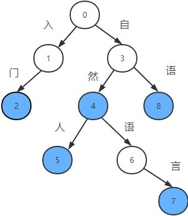

- 数字只是人为编号
- 词汇终点添加终止标记
  - 注意：不一定是叶节点

## 字典树：节点实现

```python
class Node(object):
    def __init__(self, value) -> None: # Type Hints: returns nothing
        self._children = {}
        self._value = value

    def _add_child(self, char, value, overwrite=False):
        child = self._children.get(char)
        if child is None: # None: 当前节点不对应任何词
            child = Node(value)
            self._children[char] = child
        elif overwrite:
            child._value = value
        return child
```

## 字典树：增删改查

“增删改查”的关键是查询

- **删除**：将终点设为`None`
- **修改**：将终点替换

- **增加**：无法遍历时，创建子节点

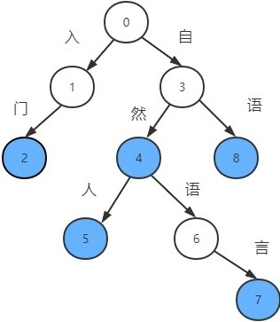

## 字典树：增删改查实现

```python
class Trie(Node):
    def __init__(self) -> None:
        super().__init__(None)

    def __contains__(self, key):
        return self[key] is not None

    def __getitem__(self, key):
        state = self
        for char in key:
            state = state._children.get(char)
            if state is None:
                return None
        return state._value

    def __setitem__(self, key, value):
        state = self
        for i, char in enumerate(key):
            if i < len(key) - 1:
                state = state._add_child(char, None, False)
            else:
                state = state._add_child(char, value, True)
```

## 散列表

问题：**起点（根节点）**怎么处理？

- 给一句话中每个字都创建`trie`？

```
北京大学位于北京市
```

- 首字（根节点）散列表
  - 散列查找
- 其余节点按`trie`构造
  - 二分查找

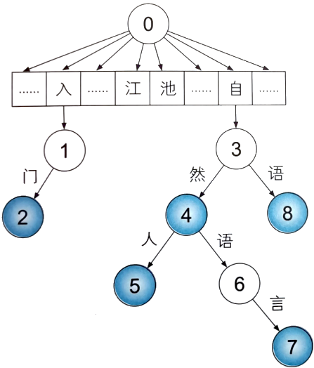

## 其他数据结构

提升匹配**速度**

- 双数组字典树 DAT
- AC (Aho-Corasick) 自动机

分词问题本身不太重要

- NLP的最终目的是语义理解，分词只是**可选预处理步骤**
  - 提升速度对预处理来说只是锦上添花
  - [Li 2019] 中文用汉字作为基本单元可以解决大多数NLP任务

词典分词的局限性

- 现代分词算法更加强调**数据本身的结构信息**
  - 主要应用机器学习；词典作为辅助信息

## Demo：HanLP 词典分词

# 评测

## 评测词典分词

|  | **T** | **F** |  |
| --- | --- | --- | --- |
| **P** | TP | FP | $P = \frac{TP}{TP+FP}$ |
| **N** | FN | TN |  |
|  | $R = \frac{TP}{TP+FN}$ |  |  |

例如：“结婚的和尚未结婚的”

- 标注：[‘结婚’, ‘的’, ‘和’, ‘尚未’, ‘结婚’, ‘的’]
- 预测：[‘结婚’, ‘的’, ‘和尚’, ‘未结婚’, ‘的’]

## 分隔转换

|  | **T** | **F** |  |
| --- | --- | --- | --- |
| **P** | TP | FP | $P = \frac{TP}{TP+FP}$ |
| **N** | FN | TN |  |
|  | $R = \frac{TP}{TP+FN}$ |  |  |

例如：“结婚的和尚未结婚的”

- 标注：[‘结婚’, ‘的’, ‘和’, ‘尚未’, ‘结婚’, ‘的’]
- 预测：[‘结婚’, ‘的’, ‘和尚’, ‘未结婚’, ‘的’]

需要将分隔**转换成分类**

- 将每个词的起止位置记作区间$[w_i,w_j]$
  - **标注真值**对应的区间集合记作$A$：$A = TP \cup FN$
  - **预测阳性**对应的区间集合记作$B$：$B = TP \cup FP$

推论：$TP = A \cap B$

- $P = \frac{|A \cap B|}{|B|}, R = \frac{|A \cap B|}{|A|}$

## 分隔转换：举例

例如：“结婚的和尚未结婚的”

[output not shown]

- $P = \frac{|A \cap B|}{|B|} = \frac{3}{5} = 60\%, R = \frac{|A \cap B|}{|A|} = \frac{3}{6} = 50\%$
- $F_1 = \frac{2 PR}{P+R} = 55\%$

## 评测：词典选用

评测与**词典粒度**

- 粒度较粗：收录的词较长，如“圆满完成”
  - 算法与评测应该使用**相同词典**

第二届国际中文分词评测 **SIGHAN05**

- **MSR** 语料集、词典

## 评测：词典未收录

评测文本中含词典未收录词条是NLP难题

- **未收录词 Out Of Vocabulary (OOV)**：俗称“新词”
  - 词典分词算法的召回率非常低
- **收录词 In Vocabulary (IV)**
  - 词典分词算法不能保证$100\%$召回

| 算法 | $P$ | $R$ | $F_1$ | $R_{OOV}$ | $R_{IV}$ |
| --- | --- | --- | --- | --- | --- |
| **最长匹配** | $91.80$ | $95.69$ | $93.71$ | $2.58$ | $98.22$ |

## 实验：评测实现

# 字典树的应用

## 停用词过滤

**停用词**：不影响解决NLP任务的词

- 无实意：助词“的”，连词“和”，副词“甚至”，语气词“啊”
- 非法：敏感词，限制级

停用词过滤是一个**预处理**过程

1. 构建停用词字典
2. 替换字典中的词

## 实验：停用词过滤

## 繁简转换

朴素繁简**对照表**：繁简分歧问题

- 一简对多繁、一繁对多简

```
发现一根白头发
發現一根白頭髮
```

- 港澳台地区习惯

常见分类：**简体 s**、**繁體 t**、**香港繁體 hk**、**台灣正體 tw**

- 总计：$P(4,2)=12$种相互转换
- 实际上只需要4种转换词典

## 实验：繁简转换

## 拼音转换

这里只讨论**汉字转成拼音**（拼音转汉字是输入法的研究内容）

- 多音字：需要提取词义
  - 简单方法：根据拼音词典按词转换

| 原文 | 重 | 载 | 不 | 是 | 重 | 任 | ！ |
| --- | --- | --- | --- | --- | --- | --- | --- |
| **数字音调** | chong2 | zai3 | bu2 | shi4 | zhong4 | ren4 | none5 |
| **符号音调** | chóng | zǎi | bú | shì | zhòng | rèn | none |
| **无音调** | chong | zai | bu | shi | zhong | ren | none |
| **声调** | 2 | 3 | 2 | 4 | 4 | 4 | 5 |
| **声母** | ch | z | b | sh | zh | r | none |
| **韵母** | ong | ai | u | i | ong | en | none |
| **输入法头** | ch | z | b | sh | zh | r | none |

## 实验：拼音转换

## 词典分词总结

- 主要数据结构：字典树
- 应用：停用词过滤、繁简转换、拼音转换
- 问题：正确率不高，无法区分歧义，无法召回新词